# 04_Biodiversity_2022

Julie Cardon

2024-04-03

# Setting the Environment

## Set the seed

```r
set.seed(19)
```

## Load Libraries

```r
pacman::p_load(tidyverse, devtools, patchwork, iNEXT, phyloseq,
               install = FALSE)
```

## Load in Data

```r
#file.exists("data/02_PreProcessing/raw_preprocessed_physeq_2022.RData")- check the knit directory
load("data/02_PreProcessing/raw_preprocessed_physeq_2022.RData")
raw_preprocessed_physeq_2022
```

```
## phyloseq-class experiment-level object
## otu_table()   OTU Table:         [ 64993 taxa and 87 samples ]
## sample_data() Sample Data:       [ 87 samples by 14 sample variables ]
## tax_table()   Taxonomy Table:    [ 64993 taxa by 9 taxonomic ranks ]
```

```r
# Intiution Check
min(sample_sums(raw_preprocessed_physeq_2022))
```

```
## [1] 638
```

```r
# Make metadata dataframe
metadata_df_2022 <-
  raw_preprocessed_physeq_2022 %>%
  sample_data() %>%
  data.frame()

head(metadata_df_2022)
```

```
##            Sample Rootstock SeqSample TreeNumber YearSampled SequencingRun
## B4_2022   B4_2022      Bud9        B4        170        2022             1
## G2_2022   G2_2022       G11        G2         59        2022             1
## G10_2022 G10_2022       G41       G10        212        2022             1
## G18_2022 G18_2022      G213       G18        110        2022             1
## G26_2022 G26_2022      G935       G26         17        2022             1
## G34_2022 G34_2022      G969       G34        146        2022             1
##                  ARD  input filtered denoisedF denoisedR merged nochim
## B4_2022  susceptible 204642   112427    101351    102867  49691  40036
## G2_2022      partial 175656   109157    102083    103425  70602  47717
## G10_2022     partial 138589    77975     71007     71865  39993  29183
## G18_2022   resistant 202865   119851    107107    110202  56371  43523
## G26_2022   resistant 202611   123029    109378    112531  54767  43778
## G34_2022   resistant 188583   117244    107780    109563  66612  51152
##          perc_reads_retained
## B4_2022             19.56392
## G2_2022             27.16503
## G10_2022            21.05723
## G18_2022            21.45417
## G26_2022            21.60692
## G34_2022            27.12440
```

```r
# Setting colors for Rootstocks
Rootstock_colors <- c(
  "Bud9" = "indianred",
  "Bud10" = "burlywood3",
  "G11" = "#D9CC3C",
  "G41" = "#A0E0BA",
  "G202" = "#00ADA7",
  "G213" = "dodgerblue4",
  "G890" = "khaki4",
  "G935" = "honeydew3",
  "G969" = "brown",
  "M7" = "palegreen4",
  "M9337" = "gold",
  "M9Nic29" = "dodgerblue3",
  "M9pajam2" = "peru",
  "V1" = "plum4",
  "G210" = "paleturquoise3",
  "Soil" = "palevioletred")
```

# Goals

1. Calculate the Hill Diversity of the samples.
2. Evaluate the rarefaction curves.
3. Evaluate the Diversity values.
4. Make notes of specific samples and their seq depth.

# Diversity Calculations with iNEXT

```r
#prepare input data
iNEXT_input_df_2022 <-
  raw_preprocessed_physeq_2022 %>%
  otu_table() %>%
  data.frame()
# Quick check
dim(iNEXT_input_df_2022)
```

```
## [1] 64993    87
```

```r
# Run iNEXT: Calculate the Hill Numbers
# Note that: Species in ROWS, Samples in COLUMNS
# Remember to set the seed!
# iNEXT_data_2022 <- iNEXT(iNEXT_input_df_2022,
                   # q = c(0,1,2), datatype = "abundance")

# Save the file
#save(iNEXT_data_2022, file = "data/04_Biodiversity/iNEXT_data_2022.RData")
load("data/04_Biodiversity/iNEXT_data_2022.RData")
```

# Evaluate the Diversity!

```r
load("data/04_Biodiversity/iNEXT_data_2022.RData")
str(iNEXT_data_2022)
```

```
## List of 3
##  $ DataInfo:'data.frame':    87 obs. of  14 variables:
##   ..$ Assemblage: chr [1:87] "B4_2022" "G2_2022" "G10_2022" "G18_2022" ...
##   ..$ n         : num [1:87] 40034 47706 29179 43520 43751 ...
##   ..$ S.obs     : num [1:87] 2297 1622 1259 2755 2922 ...
##   ..$ SC        : num [1:87] 0.996 0.998 0.997 0.996 0.995 ...
##   ..$ f1        : num [1:87] 154 74 84 175 217 127 21 192 95 142 ...
##   ..$ f2        : num [1:87] 268 218 188 356 333 232 86 348 228 259 ...
##   ..$ f3        : num [1:87] 385 269 141 547 558 369 117 607 370 405 ...
##   ..$ f4        : num [1:87] 183 161 78 297 306 210 71 329 216 276 ...
##   ..$ f5        : num [1:87] 105 88 57 165 154 120 25 156 109 117 ...
##   ..$ f6        : num [1:87] 87 76 41 78 127 74 21 134 76 94 ...
##   ..$ f7        : num [1:87] 62 40 38 89 84 73 21 82 76 75 ...
##   ..$ f8        : num [1:87] 70 60 45 86 88 79 20 84 44 59 ...
##   ..$ f9        : num [1:87] 67 49 35 62 84 41 15 78 55 59 ...
##   ..$ f10       : num [1:87] 66 33 32 49 59 50 5 58 47 49 ...
##  $ iNextEst:List of 2
##   ..$ size_based    :'data.frame':   10440 obs. of  10 variables:
##   .. ..$ Assemblage: chr [1:10440] "B4_2022" "B4_2022" "B4_2022" "B4_2022" ...
##   .. ..$ m         : num [1:10440] 1 2225 4449 6673 8897 ...
##   .. ..$ Method    : chr [1:10440] "Rarefaction" "Rarefaction" "Rarefaction" "Rarefaction" ...
##   .. ..$ Order.q   : num [1:10440] 0 0 0 0 0 0 0 0 0 0 ...
##   .. ..$ qD        : num [1:10440] 1 914 1285 1513 1674 ...
##   .. ..$ qD.LCL    : num [1:10440] 1 907 1275 1501 1660 ...
##   .. ..$ qD.UCL    : num [1:10440] 1 920 1295 1526 1688 ...
##   .. ..$ SC        : num [1:10440] 0.00329 0.77386 0.87438 0.91556 0.93769 ...
##   .. ..$ SC.LCL    : num [1:10440] 0.00319 0.77134 0.87263 0.91424 0.93663 ...
##   .. ..$ SC.UCL    : num [1:10440] 0.00339 0.77637 0.87614 0.91689 0.93875 ...
##   ..$ coverage_based:'data.frame':   10359 obs. of  8 variables:
##   .. ..$ Assemblage: chr [1:10359] "B4_2022" "B4_2022" "B4_2022" "B4_2022" ...
##   .. ..$ SC        : num [1:10359] 0.00329 0.77386 0.87438 0.91556 0.93769 ...
##   .. ..$ m         : num [1:10359] 1 2225 4449 6673 8897 ...
##   .. ..$ Method    : chr [1:10359] "Rarefaction" "Rarefaction" "Rarefaction" "Rarefaction" ...
##   .. ..$ Order.q   : num [1:10359] 0 0 0 0 0 0 0 0 0 0 ...
##   .. ..$ qD        : num [1:10359] 1 914 1285 1513 1674 ...
##   .. ..$ qD.LCL    : num [1:10359] 0.988 901.003 1268.625 1494.695 1654.601 ...
##   .. ..$ qD.UCL    : num [1:10359] 1.01 926.09 1301.56 1531.84 1694.03 ...
##  $ AsyEst  :'data.frame':    261 obs. of  7 variables:
##   ..$ Assemblage: chr [1:261] "B1_2022" "B1_2022" "B1_2022" "B10_2022" ...
##   ..$ Diversity : chr [1:261] "Species richness" "Shannon diversity" "Simpson diversity" "Species richness" ...
##   ..$ Observed  : num [1:261] 1645 336.7 64.5 763 101.9 ...
##   ..$ Estimator : num [1:261] 1679.7 345.5 64.6 779.6 103.4 ...
##   ..$ s.e.      : num [1:261] 14.37 3.67 1.21 10.97 1.09 ...
##   ..$ LCL       : num [1:261] 1651.5 338.3 62.3 763 101.2 ...
##   ..$ UCL       : num [1:261] 1708 353 67 801 106 ...
##  - attr(*, "class")= chr "iNEXT"
```

```r
typeof(iNEXT_data_2022)
```

```
## [1] "list"
```

# Plot Diversity

```r
# Prepare Colors
color_df_2022 <-
  iNEXT_input_df_2022 %>%
  colnames() %>%
  data.frame()
# Check
head(color_df_2022)
```

```
##          .
## 1  B4_2022
## 2  G2_2022
## 3 G10_2022
## 4 G18_2022
## 5 G26_2022
## 6 G34_2022
```

```r
# Rename the column
colnames(color_df_2022)[1] <- "Sample"
# Check
head(color_df_2022)
```

```
##     Sample
## 1  B4_2022
## 2  G2_2022
## 3 G10_2022
## 4 G18_2022
## 5 G26_2022
## 6 G34_2022
```

```r
#View(color_df)

# Make a helper dataframe for plotting with colors
iNEXT_color_df_2022 <-
  color_df_2022 %>% mutate(Sample = gsub(Sample, pattern = "X",  replace = "")) %>%
  # Fix the names for merging (I don't think I need to fix my sample names)
  #mutate(names = gsub(names, pattern = "[.]", replace = "-"),
        #names = gsub(names, pattern = "X",  replace = "")) %>%
  # Merge with metadata
  left_join(metadata_df_2022, by = "Sample") %>%
  # Merge with colors for plotting with ggiNEXT
  left_join(data.frame(Rootstock_colors = Rootstock_colors,
            Rootstock = names(Rootstock_colors)),
            by = "Rootstock")
#View(iNEXT_color_df_2022)
```

# Plot Rarefaction with `ggiNEXT`

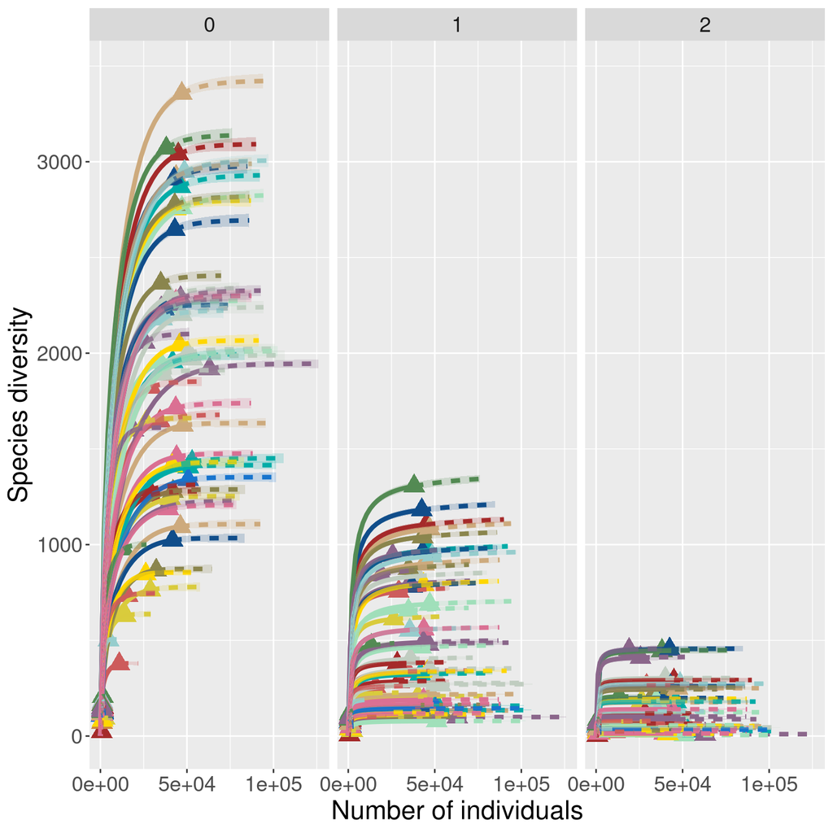

```r
# Plot rarefaction!
# rarefaction/extrapolation curve, type = 1

# Order q:
  # 0 = Richness/ Number of Total taxa
  # 1 = Exponential Shannon / Number of "Common" taxa
  # 2 = Inverse Simpson / Number of "Dominant" taxa

ggiNEXT(iNEXT_data_2022, type = 1, facet.var = "Order.q") +
  facet_wrap(~Order.q, scales = "fixed") +
  scale_color_manual(values = iNEXT_color_df_2022$Rootstock_colors, guide = FALSE) +
  scale_fill_manual(values = iNEXT_color_df_2022$Rootstock_colors, guide = FALSE) +
  scale_shape_manual(values = base::rep(17, nsamples(raw_preprocessed_physeq_2022)),
                     guide = FALSE) +
  theme(legend.position = "none")
```

# Manually plot Diversity

## Rarefaction

```r
iNEXT_manual_df_2022 <-
  iNEXT_data_2022$iNextEst$size_based %>%
  dplyr::rename(Sample = Assemblage) %>%
  # Fix the samples names
  mutate(Sample = gsub(Sample, pattern = "X", replace = "")) %>%
  # join with metadata
  left_join(., metadata_df_2022, by = "Sample") %>%
  # Add colors to data frame
  left_join(., data.frame(Rootstock_colors = Rootstock_colors,
                          Rootstock = names(Rootstock_colors)),
            by = "Rootstock")
# Inspect
dim(iNEXT_manual_df_2022)
```

```
## [1] 10440    24
```

```r
str(iNEXT_manual_df_2022)
```

```
## 'data.frame':    10440 obs. of  24 variables:
##  $ Sample             : chr  "B4_2022" "B4_2022" "B4_2022" "B4_2022" ...
##  $ m                  : num  1 2225 4449 6673 8897 ...
##  $ Method             : chr  "Rarefaction" "Rarefaction" "Rarefaction" "Rarefaction" ...
##  $ Order.q            : num  0 0 0 0 0 0 0 0 0 0 ...
##  $ qD                 : num  1 914 1285 1513 1674 ...
##  $ qD.LCL             : num  1 907 1275 1501 1660 ...
##  $ qD.UCL             : num  1 920 1295 1526 1688 ...
##  $ SC                 : num  0.00329 0.77386 0.87438 0.91556 0.93769 ...
##  $ SC.LCL             : num  0.00319 0.77134 0.87263 0.91424 0.93663 ...
##  $ SC.UCL             : num  0.00339 0.77637 0.87614 0.91689 0.93875 ...
##  $ Rootstock          : chr  "Bud9" "Bud9" "Bud9" "Bud9" ...
##  $ SeqSample          : chr  "B4" "B4" "B4" "B4" ...
##  $ TreeNumber         : chr  "170" "170" "170" "170" ...
##  $ YearSampled        : int  2022 2022 2022 2022 2022 2022 2022 2022 2022 2022 ...
##  $ SequencingRun      : int  1 1 1 1 1 1 1 1 1 1 ...
##  $ ARD                : chr  "susceptible" "susceptible" "susceptible" "susceptible" ...
##  $ input              : num  204642 204642 204642 204642 204642 ...
##  $ filtered           : num  112427 112427 112427 112427 112427 ...
##  $ denoisedF          : num  101351 101351 101351 101351 101351 ...
##  $ denoisedR          : num  102867 102867 102867 102867 102867 ...
##  $ merged             : num  49691 49691 49691 49691 49691 ...
##  $ nochim             : num  40036 40036 40036 40036 40036 ...
##  $ perc_reads_retained: num  19.6 19.6 19.6 19.6 19.6 ...
##  $ Rootstock_colors   : chr  "indianred" "indianred" "indianred" "indianred" ...
```

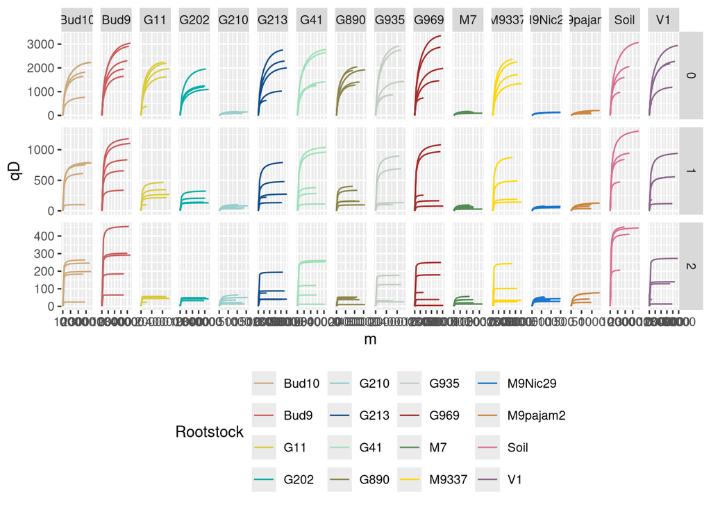

```r
#View(iNEXT_manual_df_2022)

# Plot it - Rarefaction Curve
iNEXT_manual_df_2022 %>%
  # Filter out rows that are calcaulted by rarefaction from iNEXT
  dplyr::filter(Method == "Rarefaction") %>%
  # Make the actual rarefaction plot with
  # the # of sequences on the x-axis and diversity on the y-axis
  # You can choose to pick one diversity value or plot all three
  ggplot(aes(x = m, y= qD, color = Rootstock, group = Sample)) +
  # line
  geom_line() +
  #geom_point() +
  # Challenge: Facet with the station
  facet_grid(Order.q~Rootstock, scales = "free") +
  scale_color_manual(values = Rootstock_colors) +
  theme(legend.position = "bottom")
```

It looks like the curves for richness (0) and to some extent Shannon (1) do not level off, so those measures might not be reliable. The Simpson curves, even for the shallow samples do appear to level off, and so we may want to report that as our principal measure of biodiversity.